# Проект: Анализ развлекательного приложения Procrastinate Pro+

### Конверсия пользователей и удержание по странам

| region dt | France | Germany | UK | United States |
| --- | --- | --- | --- | --- |
| 2019-05-01 | NaN | NaN | NaN | NaN |
| 2019-05-02 | NaN | NaN | NaN | NaN |
| 2019-05-03 | NaN | NaN | NaN | NaN |
| 2019-05-04 | NaN | NaN | NaN | NaN |
| 2019-05-05 | NaN | NaN | NaN | NaN |
| 2019-05-06 | NaN | NaN | NaN | NaN |
| 2019-05-07 | 0.008296 | 0.007728 | 0.000000 | 0.005511 |
| 2019-05-08 | 0.009696 | 0.007728 | 0.000000 | 0.003252 |
| 2019-05-09 | 0.004202 | 0.007728 | 0.000000 | 0.003252 |
| 2019-05-10 | 0.008063 | 0.007728 | 0.000000 | 0.002549 |
| 2019-05-11 | 0.010920 | 0.003759 | 0.000000 | 0.001574 |
| 2019-05-12 | 0.010920 | 0.003759 | 0.000000 | 0.001683 |
| 2019-05-13 | 0.015249 | 0.000000 | 0.000000 | 0.001656 |
| 2019-05-14 | 0.015249 | 0.000000 | 0.000000 | 0.001075 |
| 2019-05-15 | 0.015973 | 0.000000 | 0.000000 | 0.001075 |
| 2019-05-16 | 0.015973 | 0.004762 | 0.000000 | 0.002213 |
| 2019-05-17 | 0.012112 | 0.004762 | 0.000000 | 0.002845 |
| 2019-05-18 | 0.009255 | 0.004762 | 0.000000 | 0.003356 |
| 2019-05-19 | 0.012430 | 0.004762 | 0.003663 | 0.002775 |
| 2019-05-20 | 0.011016 | 0.004762 | 0.003663 | 0.002883 |
| 2019-05-21 | 0.011016 | 0.004762 | 0.007234 | 0.002883 |
| 2019-05-22 | 0.006090 | 0.004762 | 0.007234 | 0.002883 |
| 2019-05-23 | 0.006090 | 0.003571 | 0.007234 | 0.002374 |
| 2019-05-24 | 0.006090 | 0.008333 | 0.007234 | 0.001742 |
| 2019-05-25 | 0.006090 | 0.008333 | 0.007234 | 0.002384 |
| 2019-05-26 | 0.002915 | 0.012798 | 0.003571 | 0.002911 |
| 2019-05-27 | 0.000000 | 0.016369 | 0.003571 | 0.002919 |
| 2019-05-28 | 0.000000 | 0.016369 | 0.000000 | 0.002919 |
| 2019-05-29 | 0.002132 | 0.016369 | 0.000000 | 0.002919 |
| 2019-05-30 | 0.002132 | 0.012798 | 0.000000 | 0.002290 |

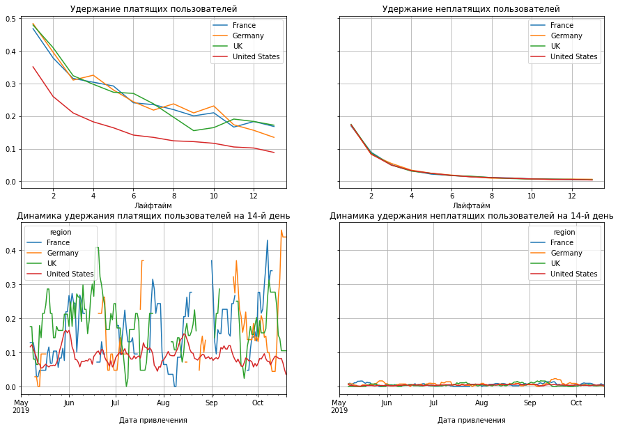

```python
# удержание пользователей
retention_raw, retention, retention_history = get_retention(profiles,
                                                            visits,
                                                            datetime(2019, 11, 1).date(),
                                                            analysis_horizon,
                                                            dimensions=['region']
                                                           )
plot_retention(retention,
               retention_history,
               analysis_horizon,
               window=7)
```

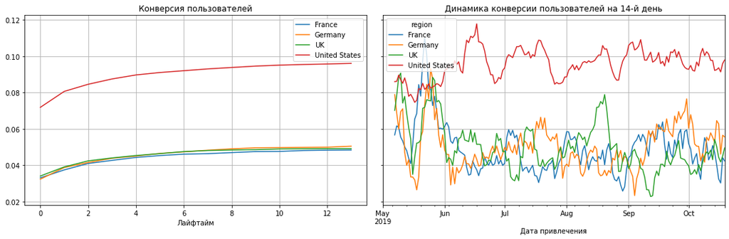

```python
conversion_raw, conversion, conversion_history = get_conversion(profiles,
                                                                orders,
                                                                observation_date,
                                                                analysis_horizon,
                                                                dimensions=['region']
                                                               )

plot_conversion(conversion,
                conversion_history,
                analysis_horizon,
                window=7)
```

> Несмотря на то, что **показатели удержания пользователей из США самые низкие, то конверсия пользователей намного выше, чем в других странах. То есть пользователь совершил целевое действие, но не вернулся за продуктом. Возможно дело в приложении.**  
> **В мае с европейскими странами происходило что-то интересное. В середине месяца конверсия упала, а затем резко выросла, однако вскоре снова упала до того же уровня.**

### Конверсия пользователей и удержание по устройствам

| device dt | Android | Mac | PC | iPhone |
| --- | --- | --- | --- | --- |
| 2019-05-01 | NaN | NaN | NaN | NaN |
| 2019-05-02 | NaN | NaN | NaN | NaN |
| 2019-05-03 | NaN | NaN | NaN | NaN |
| 2019-05-04 | NaN | NaN | NaN | NaN |
| 2019-05-05 | NaN | NaN | NaN | NaN |
| 2019-05-06 | NaN | NaN | NaN | NaN |
| 2019-05-07 | 0.006210 | 0.005895 | 0.008367 | 0.003206 |
| 2019-05-08 | 0.008166 | 0.002232 | 0.006099 | 0.001058 |
| 2019-05-09 | 0.008166 | 0.002232 | 0.003678 | 0.001058 |
| 2019-05-10 | 0.008166 | 0.000000 | 0.005810 | 0.001058 |
| 2019-05-11 | 0.004920 | 0.000000 | 0.005685 | 0.001058 |
| 2019-05-12 | 0.003477 | 0.002304 | 0.005685 | 0.001058 |
| 2019-05-13 | 0.003638 | 0.002304 | 0.005727 | 0.001058 |
| 2019-05-14 | 0.003638 | 0.002304 | 0.005727 | 0.000000 |
| 2019-05-15 | 0.001681 | 0.002304 | 0.005727 | 0.001348 |
| 2019-05-16 | 0.003169 | 0.002304 | 0.008108 | 0.002528 |
| 2019-05-17 | 0.003169 | 0.004375 | 0.005976 | 0.002528 |
| 2019-05-18 | 0.003169 | 0.004375 | 0.005930 | 0.002528 |
| 2019-05-19 | 0.003169 | 0.002070 | 0.007835 | 0.003594 |
| 2019-05-20 | 0.003189 | 0.002070 | 0.007976 | 0.003594 |
| 2019-05-21 | 0.003189 | 0.002070 | 0.009933 | 0.003594 |
| 2019-05-22 | 0.003189 | 0.002070 | 0.009933 | 0.002247 |
| 2019-05-23 | 0.001701 | 0.004533 | 0.009750 | 0.001066 |
| 2019-05-24 | 0.003532 | 0.002463 | 0.009750 | 0.001066 |
| 2019-05-25 | 0.005296 | 0.004164 | 0.007964 | 0.001066 |
| 2019-05-26 | 0.005296 | 0.004164 | 0.010324 | 0.000000 |
| 2019-05-27 | 0.003595 | 0.004164 | 0.010431 | 0.001107 |
| 2019-05-28 | 0.003595 | 0.004164 | 0.008474 | 0.001107 |
| 2019-05-29 | 0.003595 | 0.004164 | 0.008474 | 0.001910 |
| 2019-05-30 | 0.003595 | 0.001701 | 0.006276 | 0.001910 |

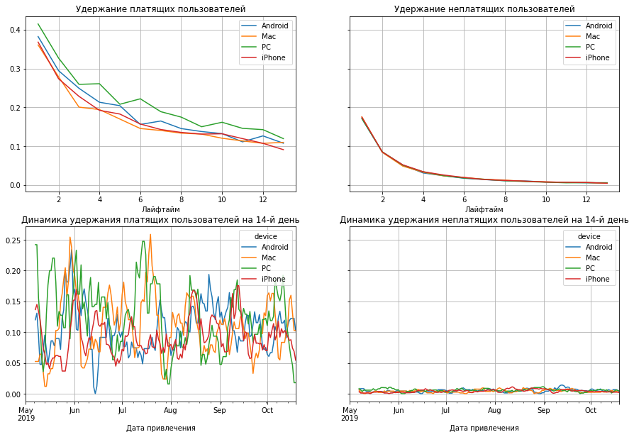

```python
# удержание пользователей
retention_raw, retention, retention_history = get_retention(profiles,
                                                            visits,
                                                            datetime(2019, 11, 1).date(),
                                                            analysis_horizon,
                                                            dimensions=['device']
                                                           )
plot_retention(retention,
               retention_history,
               analysis_horizon,
               window=7)
```

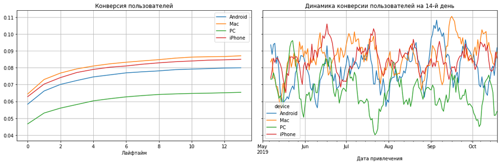

```python
conversion_raw, conversion, conversion_history = get_conversion(profiles,
                                                                orders,
                                                                observation_date,
                                                                analysis_horizon,
                                                                dimensions=['device']
                                                               )

plot_conversion(conversion,
                conversion_history,
                analysis_horizon,
                window=7)
```

> Удержание пользователей по девайсам в рамках нормы. Самый высокий показатель удержания у пользователей **PC**. Однако, самая низкая конверсия тоже у пользователей **PC**. **Возможно проблемы с аутентификацией приложения через PC**, можно добавить автозаполнение при входе или вход через сторонние ресурсы.

### Конверсия пользователей и удержание по каналам

| channel dt | AdNonSense | FaceBoom | LeapBob | MediaTornado | OppleCreativeMedia | RocketSuperAds | TipTop | WahooNetBanner | YRabbit | lambdaMediaAds |
| --- | --- | --- | --- | --- | --- | --- | --- | --- | --- | --- |
| 2019-05-01 | NaN | NaN | NaN | NaN | NaN | NaN | NaN | NaN | NaN | NaN |
| 2019-05-02 | NaN | NaN | NaN | NaN | NaN | NaN | NaN | NaN | NaN | NaN |
| 2019-05-03 | NaN | NaN | NaN | NaN | NaN | NaN | NaN | NaN | NaN | NaN |
| 2019-05-04 | NaN | NaN | NaN | NaN | NaN | NaN | NaN | NaN | NaN | NaN |
| 2019-05-05 | NaN | NaN | NaN | NaN | NaN | NaN | NaN | NaN | NaN | NaN |
| 2019-05-06 | NaN | NaN | NaN | NaN | NaN | NaN | NaN | NaN | NaN | NaN |
| 2019-05-07 | 0.011905 | 0.004642 | 0.007143 | 0.003106 | 0.000000 | 0.004926 | 0.009312 | 0.000000 | 0.005291 | 0.000000 |
| 2019-05-08 | 0.007937 | 0.001570 | 0.014286 | 0.003106 | 0.000000 | 0.004926 | 0.007356 | 0.000000 | 0.000000 | 0.000000 |
| 2019-05-09 | 0.003968 | 0.001570 | 0.014286 | 0.003106 | 0.000000 | 0.004926 | 0.007356 | 0.000000 | 0.000000 | 0.000000 |
| 2019-05-10 | 0.003968 | 0.001570 | 0.014286 | 0.003106 | 0.006803 | 0.004926 | 0.004608 | 0.000000 | 0.000000 | 0.000000 |
| 2019-05-11 | 0.003968 | 0.001570 | 0.007143 | 0.003106 | 0.006803 | 0.004926 | 0.000000 | 0.000000 | 0.000000 | 0.006803 |
| 2019-05-12 | 0.003968 | 0.003425 | 0.007143 | 0.000000 | 0.006803 | 0.004926 | 0.000000 | 0.000000 | 0.000000 | 0.006803 |
| 2019-05-13 | 0.000000 | 0.001855 | 0.007143 | 0.003571 | 0.017792 | 0.004926 | 0.000000 | 0.000000 | 0.000000 | 0.006803 |
| 2019-05-14 | 0.000000 | 0.001855 | 0.007143 | 0.003571 | 0.017792 | 0.000000 | 0.000000 | 0.000000 | 0.000000 | 0.006803 |
| 2019-05-15 | 0.000000 | 0.001855 | 0.000000 | 0.003571 | 0.025728 | 0.000000 | 0.000000 | 0.000000 | 0.000000 | 0.006803 |
| 2019-05-16 | 0.004608 | 0.005066 | 0.000000 | 0.003571 | 0.025728 | 0.000000 | 0.000000 | 0.000000 | 0.000000 | 0.006803 |
| 2019-05-17 | 0.004608 | 0.005066 | 0.000000 | 0.003571 | 0.018926 | 0.000000 | 0.002421 | 0.000000 | 0.000000 | 0.006803 |
| 2019-05-18 | 0.004608 | 0.005066 | 0.000000 | 0.007331 | 0.018926 | 0.000000 | 0.002421 | 0.000000 | 0.000000 | 0.000000 |
| 2019-05-19 | 0.011102 | 0.003210 | 0.000000 | 0.007331 | 0.018926 | 0.000000 | 0.002421 | 0.000000 | 0.000000 | 0.000000 |
| 2019-05-20 | 0.011102 | 0.004952 | 0.006803 | 0.003759 | 0.007937 | 0.000000 | 0.002421 | 0.000000 | 0.000000 | 0.000000 |
| 2019-05-21 | 0.011102 | 0.004952 | 0.006803 | 0.003759 | 0.017460 | 0.000000 | 0.002421 | 0.000000 | 0.000000 | 0.000000 |
| 2019-05-22 | 0.011102 | 0.004952 | 0.006803 | 0.003759 | 0.009524 | 0.000000 | 0.002421 | 0.000000 | 0.000000 | 0.000000 |
| 2019-05-23 | 0.006494 | 0.003463 | 0.006803 | 0.003759 | 0.009524 | 0.000000 | 0.002421 | 0.011905 | 0.000000 | 0.000000 |
| 2019-05-24 | 0.006494 | 0.003463 | 0.006803 | 0.003759 | 0.009524 | 0.000000 | 0.000000 | 0.019048 | 0.000000 | 0.000000 |
| 2019-05-25 | 0.006494 | 0.003463 | 0.006803 | 0.004329 | 0.009524 | 0.000000 | 0.000000 | 0.019048 | 0.003759 | 0.000000 |
| 2019-05-26 | 0.000000 | 0.004811 | 0.006803 | 0.004329 | 0.016667 | 0.000000 | 0.000000 | 0.019048 | 0.003759 | 0.000000 |
| 2019-05-27 | 0.002801 | 0.003069 | 0.000000 | 0.004329 | 0.016667 | 0.000000 | 0.002551 | 0.019048 | 0.003759 | 0.000000 |
| 2019-05-28 | 0.002801 | 0.003069 | 0.000000 | 0.004329 | 0.007143 | 0.000000 | 0.002551 | 0.019048 | 0.003759 | 0.000000 |
| 2019-05-29 | 0.002801 | 0.003069 | 0.003401 | 0.004329 | 0.007143 | 0.000000 | 0.002551 | 0.019048 | 0.003759 | 0.000000 |
| 2019-05-30 | 0.002801 | 0.001348 | 0.003401 | 0.004329 | 0.007143 | 0.000000 | 0.002551 | 0.007143 | 0.003759 | 0.000000 |

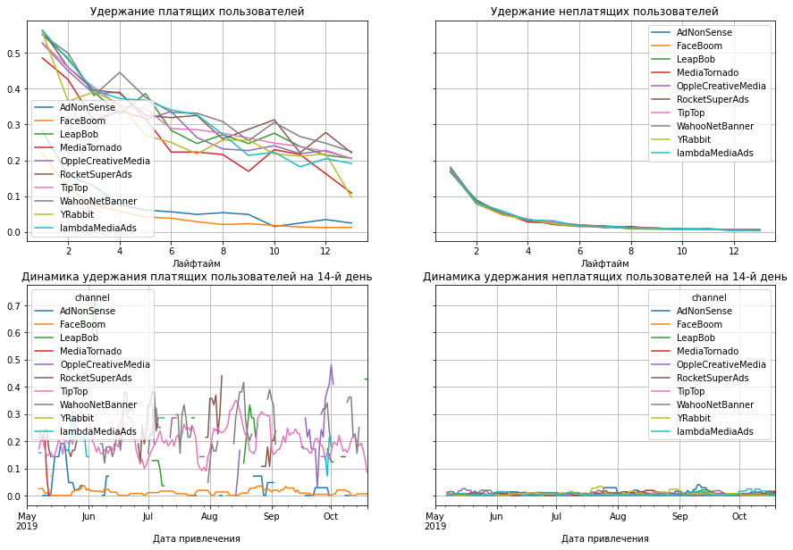

```python
# удержание пользователей
retention_raw, retention, retention_history = get_retention(profiles,
                                                            visits,
                                                            datetime(2019, 11, 1).date(),
                                                            analysis_horizon,
                                                            dimensions=['channel']
                                                           )
plot_retention(retention,
               retention_history,
               analysis_horizon,
               window=7)
```

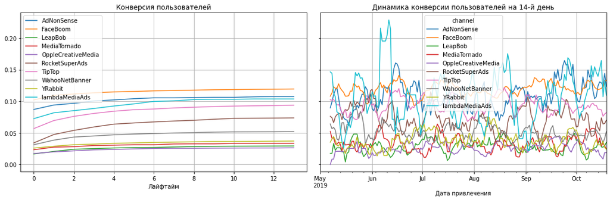

```python
conversion_raw, conversion, conversion_history = get_conversion(profiles,
                                                                orders,
                                                                observation_date,
                                                                analysis_horizon,
                                                                dimensions=['channel']
                                                               )

plot_conversion(conversion,
                conversion_history,
                analysis_horizon,
                window=7)
```

> Несмотря на низкие показатели удержания у таких каналов, как **FaceBoom и AdNonSense**, **конверсия пользователей из этого канала самая лучшая. Пользователи из этих каналов слабо конвертируются в постоянных.** Скорее всего на это влияет **качество аудитории пришедшей из этих каналов**, и, стобы улучшить метрики, стоит **сфокусироваться на каналах, отражающих ценность продукта.**